# Practical Machine Learning Project

# Predicting Barbell Performance with Accelorometer Data

## Data Processing

The description of the dataset reads: “Six young health participants were asked to perform one set of 10 repetitions of the Unilateral Dumbbell Biceps Curl in five different fashions: exactly according to the specification (Class A), throwing the elbows to the front (Class B), lifting the dumbbell only halfway (Class C), lowering the dumbbell only halfway (Class D) and throwing the hips to the front (Class E).” The training dataset contains the exercise performance class to predict (named “classe”) and 151 columns of features measured.

```r
# Downloading train and test files from Coursera Weightlifting Exercise
# Dataset
fileURL.train <- "http://d396qusza40orc.cloudfront.net/predmachlearn/pml-training.csv"
fileURL.test <- "http://d396qusza40orc.cloudfront.net/predmachlearn/pml-testing.csv"

if (!file.exists("data")) {
    dir.create("data")
}

temp.train <- "C:/Users/ENVY/Documents/pml-training.csv"
download.file(fileURL.train, temp.train)
temp.test <- "C:/Users/ENVY/Documents/pml-testing.csv"
download.file(fileURL.test, temp.test)

# Load the data into R
rawdata.train <- read.csv("C:/Users/ENVY/Documents/pml-training.csv", na.strings = "NA", header = T,
    stringsAsFactors = F)
rawdata.test <- read.csv("C:/Users/ENVY/Documents/pml-testing.csv", na.strings = "NA", header = T,
    stringsAsFactors = F)
names(rawdata.train)
```

```
##   [1] "X"                        "user_name"
##   [3] "raw_timestamp_part_1"     "raw_timestamp_part_2"
##   [5] "cvtd_timestamp"           "new_window"
##   [7] "num_window"               "roll_belt"
##   [9] "pitch_belt"               "yaw_belt"
##  [11] "total_accel_belt"         "kurtosis_roll_belt"
##  [13] "kurtosis_picth_belt"      "kurtosis_yaw_belt"
##  [15] "skewness_roll_belt"       "skewness_roll_belt.1"
##  [17] "skewness_yaw_belt"        "max_roll_belt"
##  [19] "max_picth_belt"           "max_yaw_belt"
##  [21] "min_roll_belt"            "min_pitch_belt"
##  [23] "min_yaw_belt"             "amplitude_roll_belt"
##  [25] "amplitude_pitch_belt"     "amplitude_yaw_belt"
##  [27] "var_total_accel_belt"     "avg_roll_belt"
##  [29] "stddev_roll_belt"         "var_roll_belt"
```

[output cut: 65 more lines]

The datatset was originally used by the authors to characterize the performance classes by identifying the most relevant features. The data comes with the column “new_window” identifying a pre-determined time window to calculate the features of the distributions of the measurements. When “yes”, the features fill the columns of max/min value, averag, skewness, etc. Since the test set has only 20 observations to predict with, these columns can not be calculated in the testing phase and so will be dropped in the training phase.

```r
# Remove all feature columns
feature.cols <- grep("^max|^min|^ampl|^var|^avg|^stdd|^ske|^kurt", names(rawdata.train))
tidy <- rawdata.train[-feature.cols]
tidy$classe <- factor(tidy$classe)
```

## Exploring Predictors and Response

Predictors (52) and response (1 with 5 levels) were assigned before starting training. The tidy dataset was partitioned to create a sample for training (75%) and a sample for validation. The training sample was used for further exploring. The validation data was kept untouched.

```r
require(caret)
predictors.names <- names(tidy)[8:59]
response.names <- "classe"

predictors <- tidy[predictors.names]
response <- tidy[[response.names]]

# Partition data set for training and validation
inTrain <- createDataPartition(response, p = 3/4, list = F)
trainPred <- predictors[inTrain, ]
testPred <- predictors[-inTrain, ]
trainResp <- response[inTrain]
testResp <- response[-inTrain]
```

The performance classes in the response appear slightly unbalanced with class *A* having more observations.

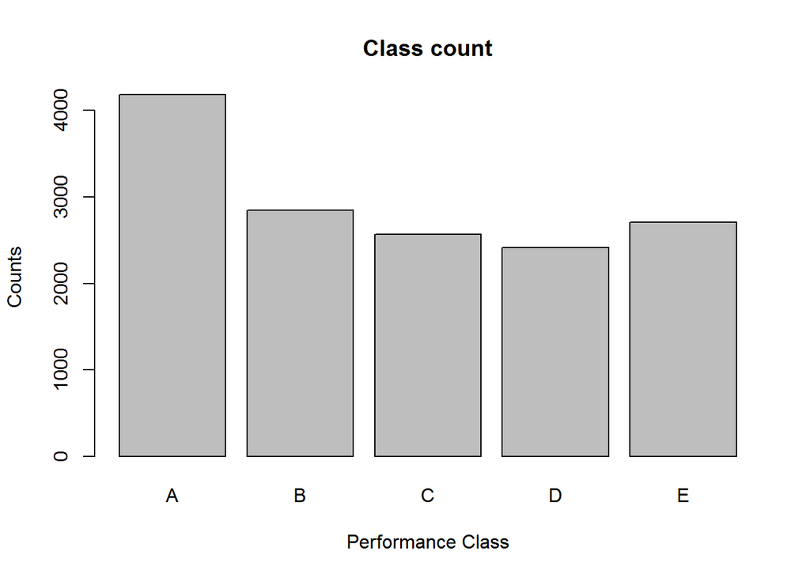

```r
plot(trainResp, xlab = "Performance Class", ylab = "Counts",main="Class count")
```

All the predictors were plotted to identify any extreme value. Raw plots highlighted few cases of abnormal values. An example is shown below. These values were removed from the dataset.

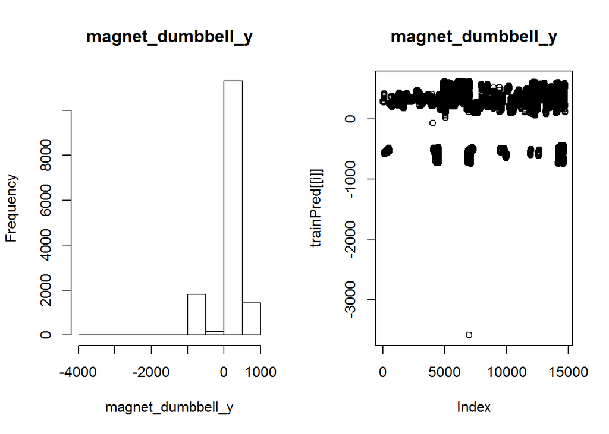

```r
# Explore histos. Do we need additional transformations?
par(mfrow = c(1, 2))
for (i in 1:ncol(trainPred)) {
    if (names(trainPred[i]) == "magnet_dumbbell_y") {
        hist(trainPred[[i]], xlab = names(trainPred[i]), main = names(trainPred[i]))
        plot(trainPred[[i]], main = names(trainPred[i]))
        # qqnorm(trainPred[[i]], main=names(trainPred[i]))
    }
}
```

```r
# Abnormal values removal
abn.rows <- trainPred$gyros_dumbbell_y > 10 | trainPred$gyros_forearm_z > 50 |
    trainPred$gyros_forearm_y > 50 | trainPred$gyros_forearm_x < -10 | trainPred$total_accel_forearm >
    100 | trainPred$magnet_dumbbell_y < -2000

trainPred <- trainPred[!abn.rows, ]
trainResp <- trainResp[!abn.rows]
```

## Preprocessing

The training sample was preprocessed to reduce the number of variables. All predictors were scaled and centered. A PCA was performed to keep the principal components explaining 90% of the data variation in the predictors.

```r
preObj <- preProcess(x = trainPred, method = c("center", "scale", "pca"), thresh = 0.9)
trainPred.pre <- predict(preObj, trainPred)
print(preObj)
```

```
##
## Call:
## preProcess.default(x = trainPred, method = c("center", "scale",
##  "pca"), thresh = 0.9)
##
## Created from 14716 samples and 52 variables
## Pre-processing: centered, scaled, principal component signal extraction
##
## PCA needed 20 components to capture 90 percent of the variance
```

## Modeling

Since many trials were needed during the optimization phase of the GBM modeling tool, only ¼ of the whole dataset was initially used to reduce computation time. Also, preprocessing with PCA was performed to keep fewer components (60% of variation explained). A 5-fold cross-validation was used to estimate the out of sample error. Once the final settings of the GBM model were determined, the model was used to fit the training sample.

```r
# CV on training data, 5-fold
train.control <- trainControl(method = "cv", number = 5)

# To use with a smaller dataset gbmGrid <- expand.grid(.interaction.depth =
# c(1,3,5,7,10,15,20), .n.trees = (1:6)*50, .shrinkage = c(0.1)) Final
# settings
gbmGrid <- expand.grid(.interaction.depth = 20, .n.trees = 300, .shrinkage = 0.1)

gbmFit <- train(trainPred.pre, trainResp, method = "gbm", trControl = train.control,
    verbose = FALSE, bag.fraction = 0.5, tuneGrid = gbmGrid)  #, metric='Kappa')
gbmFit
```

```
## Stochastic Gradient Boosting
##
## 14716 samples
##    20 predictors
##     5 classes: 'A', 'B', 'C', 'D', 'E'
##
## No pre-processing
## Resampling: Cross-Validated (5 fold)
##
## Summary of sample sizes: 11775, 11771, 11771, 11773, 11774
##
## Resampling results
##
##   Accuracy  Kappa  Accuracy SD  Kappa SD
##   1         1      0.003        0.004
##
## Tuning parameter 'n.trees' was held constant at a value of 300
##
## Tuning parameter 'interaction.depth' was held constant at a value of
##  20
## Tuning parameter 'shrinkage' was held constant at a value of 0.1
##
```

```r
# plot(gbmFit, metric='Accuracy')
```

## Model Performace - Validation Sample

The model created was used to predict the “classe” variable of the validation set. The confusion matrix below shows the expected prediction performance on an independent set. The accuracy shows the expected out of sample error expected when predicting on an independent sample.

```r
# Since there was preProc, use this info here
models <- list(gbm = gbmFit)
testPred.pre <- predict(preObj, testPred)
predict.test <- predict(models, newdata = testPred.pre)
predict.test.values <- extractPrediction(models, testX = testPred.pre, testY = testResp)
# head(predict.test.values)
testValue.test <- subset(predict.test.values, dataType == "Test")
# table(testValue.test)

conf <- caret::confusionMatrix(testValue.test$obs, testValue.test$pred)
conf
```

```
## Confusion Matrix and Statistics
##
##           Reference
## Prediction    A    B    C    D    E
##          A 1377   14    2    2    0
##          B   17  903   21    4    4
##          C    1   10  828   15    1
##          D    4    2   30  765    3
##          E    2    9    9    7  874
##
## Overall Statistics
##
##                Accuracy : 0.968
##                  95% CI : (0.963, 0.973)
##     No Information Rate : 0.286
##     P-Value [Acc > NIR] : <2e-16
##
##                   Kappa : 0.96
##  Mcnemar's Test P-Value : 0.0116
##
## Statistics by Class:
##
##                      Class: A Class: B Class: C Class: D Class: E
## Sensitivity             0.983    0.963    0.930    0.965    0.991
## Specificity             0.995    0.988    0.993    0.991    0.993
## Pos Pred Value          0.987    0.952    0.968    0.951    0.970
## Neg Pred Value          0.993    0.991    0.985    0.993    0.998
## Prevalence              0.286    0.191    0.181    0.162    0.180
## Detection Rate          0.281    0.184    0.169    0.156    0.178
## Detection Prevalence    0.284    0.194    0.174    0.164    0.184
## Balanced Accuracy       0.989    0.976    0.962    0.978    0.992
```

```r
setwd("C:/Users/ENVY/Desktop/testcase")
answers <- predict(gbmFit,rawdata.test)
pml_write_files = function(x){
  n = length(x)
  for(i in 1:n){
    filename = paste0("problem_id_",i,".txt")
    write.table(x[i],file=filename,quote=FALSE,row.names=FALSE,col.names=FALSE)
  }
}
pml_write_files(answers)
```